# Soluciones 7

Sergio Camiz

2025-06-04

## 1 Construir una carpeta Ejercicio 7

## 2 Cargar desde Paideia:

```
Iris.csv   datos de Iris de Fisher: se trata de 150 mediciones de tamaño y ancho de sepalos y petalos de 3 especies de iris y colocarlos en Rstudio como siempre
```

```r
iris                <- read.csv("Iris.csv",row.names = 1,header=TRUE)
iris$Sepal.Length   <- factor(iris$Sepal.length)
head(iris)
```

```
##   Sepal.length Sepal.width Petal.length Petal.width Species Sepal.Length
## 1          5.1         3.5          1.4         0.2  setosa          5.1
## 2          4.9         3.0          1.4         0.2  setosa          4.9
## 3          4.7         3.2          1.3         0.2  setosa          4.7
## 4          4.6         3.1          1.5         0.2  setosa          4.6
## 5          5.0         3.6          1.4         0.2  setosa            5
## 6          5.4         3.9          1.7         0.4  setosa          5.4
```

## 3 con Iris calcular una tabla de “breakdown”,

para las 4 mediciones con respecto a las especies, o sea, por cada clase, frecuencia, promedio, varianza, desvío estándar.

*Se construyen funciones que proporcionen los intervales de confianza y que hagan la tabla misma.*

```r
sum.lm              <- function(lmod) {
summ                <- summary(lmod)
ci                  <- confint(lmod)
summ$coefficients   <- cbind(summ$coefficients[,1],
                             ci,summ$coefficients[,2:4])
summ
}
```

```r
breakd              <- function(num,nom){
  res               <- list()
  nomnum            <- deparse(substitute(num))             # nombre variable numérica
  nomnom            <- deparse(substitute(nom))             # nombre variable nominal
  tab               <- table(nom)                           # distribución nominal
  nomval            <- names(tab)                           # nombres niveles
  nval              <- length(nomval)                       # número de niveles
  s_s               <- as.numeric(tab)                      # frecuencias
  s_m               <- tapply(num,nom,mean)                 # promedios
  s_ve              <- tapply(num,nom,var)                  # varianza (estimación)
  v_brk             <- rbind(s_s,s_m,s_ve)                  # se construye la tabla
  tot               <- c(sum(tab),mean(num),var(num))    # se calculan por el total
  v_brk             <- cbind(v_brk,tot)                  # ajuntando totales
  dimnames(v_brk)   <- list(statistics=c("count","mean","variance"),
                            class=c(nomval,nomnum))
  res            <- round(v_brk,3)                          # salida
    boxplot(num~nom, range=1.5, at=1:nval,xlab = nomnom,ylab = nomnum)
    inf             <- s_m-2*sqrt(s_ve)
    sup             <- s_m+2*sqrt(s_ve)
    points(1:nval,s_m,pch=20, col="red")
    points(1:nval,sup,pch=20, col="blue")
    points(1:nval,inf,pch=20, col="blue")
  res
}
```

## 4 correr test de Levine y Shapiro

para averiguar la homocedasticidad y la normalidad.

## 5 correr el ANOVA

con el modelo lineal si lo test se lo permiten: averiguar la correcta estimación de los promedios.

*La estimación de los promedio se consigue tirando la intercepta*

*### Anova de Sepal.length*

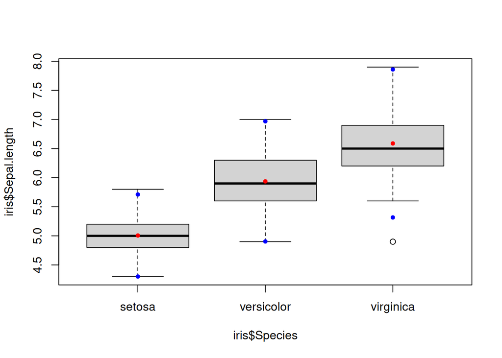

```
##           class
## statistics setosa versicolor virginica iris$Sepal.length
##   count    50.000     50.000    50.000           150.000
##   mean      5.006      5.936     6.588             5.843
##   variance  0.124      0.266     0.404             0.686
```

```r
attach(iris)
breakd(iris$Sepal.length,iris$Species)
```

```r
lm1                 <- lm(Sepal.length~Species-1)
sum.lm(lm1)
```

```
##
## Call:
## lm(formula = Sepal.length ~ Species - 1)
##
## Residuals:
##     Min      1Q  Median      3Q     Max
## -1.6880 -0.3285 -0.0060  0.3120  1.3120
##
## Coefficients:
##                           2.5 % 97.5 % Std. Error t value Pr(>|t|)
## Speciessetosa     5.0060 4.8621 5.1499     0.0728   68.76   <2e-16 ***
## Speciesversicolor 5.9360 5.7921 6.0799     0.0728   81.54   <2e-16 ***
## Speciesvirginica  6.5880 6.4441 6.7319     0.0728   90.49   <2e-16 ***
## ---
## Signif. codes:  0 '***' 0.001 '**' 0.01 '*' 0.05 '.' 0.1 ' ' 1
##
## Residual standard error: 0.5148 on 147 degrees of freedom
## Multiple R-squared:  0.9925, Adjusted R-squared:  0.9924
## F-statistic:  6522 on 3 and 147 DF,  p-value: < 2.2e-16
```

```r
cat("n prueba de homocedasticidad \n")
```

```
## n prueba de homocedasticidad
```

```r
ncvTest(lm1)                                                # NCV test
```

```
## Non-constant Variance Score Test
## Variance formula: ~ fitted.values
## Chisquare = 13.84609, Df = 1, p = 0.00019841
```

```r
cat("n prueba de normalidad \n")
```

```
## n prueba de normalidad
```

```r
shapiro.test(lm1$residuals)
```

```
##
##  Shapiro-Wilk normality test
##
## data:  lm1$residuals
## W = 0.9879, p-value = 0.2189
```

```r
Anova(lm1)
```

```
## Anova Table (Type II tests)
##
## Response: Sepal.length
##           Sum Sq  Df F value    Pr(>F)
## Species   5184.9   3  6521.7 < 2.2e-16 ***
## Residuals   39.0 147
## ---
## Signif. codes:  0 '***' 0.001 '**' 0.01 '*' 0.05 '.' 0.1 ' ' 1
```

*Los promedios de Sepal.lenght explican 99% de la varianza total. La distribución es normal, pero no pasa el test de homoscedasticidad, ya que las varianzas 0.12, 0.26, y 0.396 son demasiado diferentes. Por lo tanto la prueba Anova no se puede aplicar. Por otro lado, se ve que los promedios 5.006, 5.936 y 6.588 son correctamente estimados.*

*### Anova de Sepal.width*

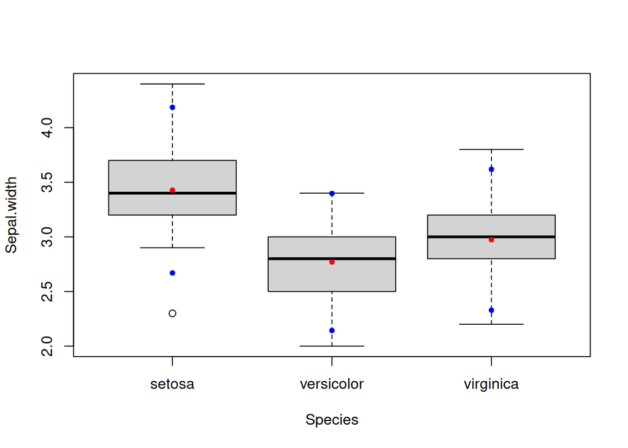

```
##           class
## statistics setosa versicolor virginica Sepal.width
##   count    50.000     50.000    50.000     150.000
##   mean      3.428      2.770     2.974       3.057
##   variance  0.144      0.098     0.104       0.190
```

```r
breakd(Sepal.width,Species)
```

```r
lm2                 <- lm(Sepal.width~Species-1)
sum.lm(lm2)
```

```
##
## Call:
## lm(formula = Sepal.width ~ Species - 1)
##
## Residuals:
##    Min     1Q Median     3Q    Max
## -1.128 -0.228  0.026  0.226  0.972
##
## Coefficients:
##                             2.5 %  97.5 % Std. Error t value Pr(>|t|)
## Speciessetosa     3.42800 3.33306 3.52294    0.04804   71.36   <2e-16 ***
## Speciesversicolor 2.77000 2.67506 2.86494    0.04804   57.66   <2e-16 ***
## Speciesvirginica  2.97400 2.87906 3.06894    0.04804   61.91   <2e-16 ***
## ---
## Signif. codes:  0 '***' 0.001 '**' 0.01 '*' 0.05 '.' 0.1 ' ' 1
##
## Residual standard error: 0.3397 on 147 degrees of freedom
## Multiple R-squared:  0.9881, Adjusted R-squared:  0.9879
## F-statistic:  4083 on 3 and 147 DF,  p-value: < 2.2e-16
```

```r
cat("n prueba de homocedasticidad \n")
```

```
## n prueba de homocedasticidad
```

```r
ncvTest(lm2)                                                # NCV test
```

```
## Non-constant Variance Score Test
## Variance formula: ~ fitted.values
## Chisquare = 2.198817, Df = 1, p = 0.13812
```

```r
cat("n prueba de normalidad \n")
```

```
## n prueba de normalidad
```

```r
shapiro.test(lm2$residuals)
```

```
##
##  Shapiro-Wilk normality test
##
## data:  lm2$residuals
## W = 0.98948, p-value = 0.323
```

```r
Anova(lm2)
```

```
## Anova Table (Type II tests)
##
## Response: Sepal.width
##            Sum Sq  Df F value    Pr(>F)
## Species   1413.44   3  4083.2 < 2.2e-16 ***
## Residuals   16.96 147
## ---
## Signif. codes:  0 '***' 0.001 '**' 0.01 '*' 0.05 '.' 0.1 ' ' 1
```

*En el caso de Sepal.width las pruebas confirman que los residuos sono homocedastícos y normales. Efectivamente las varianzas resultan bastante parecidas: 0.141, 0.097 y 0.102. La diferencia entre promedios 3.428, 2.770 y 2.974 explica 98.8% de la varianza total.*

*### Anova de Petal.length*

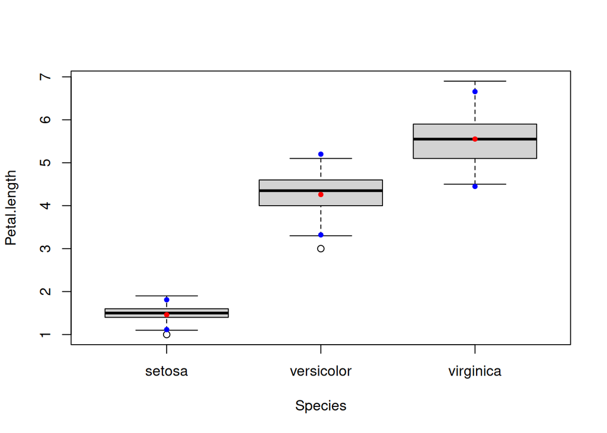

```
##           class
## statistics setosa versicolor virginica Petal.length
##   count    50.000     50.000    50.000      150.000
##   mean      1.462      4.260     5.552        3.758
##   variance  0.030      0.221     0.305        3.116
```

```r
breakd(Petal.length,Species)
```

```r
lm3                 <- lm(Petal.length~Species-1)
sum.lm(lm3)
```

```
##
## Call:
## lm(formula = Petal.length ~ Species - 1)
##
## Residuals:
##    Min     1Q Median     3Q    Max
## -1.260 -0.258  0.038  0.240  1.348
##
## Coefficients:
##                             2.5 %  97.5 % Std. Error t value Pr(>|t|)
## Speciessetosa     1.46200 1.34173 1.58227    0.06086   24.02   <2e-16 ***
## Speciesversicolor 4.26000 4.13973 4.38027    0.06086   70.00   <2e-16 ***
## Speciesvirginica  5.55200 5.43173 5.67227    0.06086   91.23   <2e-16 ***
## ---
## Signif. codes:  0 '***' 0.001 '**' 0.01 '*' 0.05 '.' 0.1 ' ' 1
##
## Residual standard error: 0.4303 on 147 degrees of freedom
## Multiple R-squared:  0.9895, Adjusted R-squared:  0.9892
## F-statistic:  4600 on 3 and 147 DF,  p-value: < 2.2e-16
```

```r
cat("n prueba de homocedasticidad \n")
```

```
## n prueba de homocedasticidad
```

```r
ncvTest(lm3)                                                # NCV test
```

```
## Non-constant Variance Score Test
## Variance formula: ~ fitted.values
## Chisquare = 28.8342, Df = 1, p = 7.8847e-08
```

```r
cat("n prueba de normalidad \n")
```

```
## n prueba de normalidad
```

```r
shapiro.test(lm3$residuals)
```

```
##
##  Shapiro-Wilk normality test
##
## data:  lm3$residuals
## W = 0.98108, p-value = 0.03676
```

```r
Anova(lm3)
```

```
## Anova Table (Type II tests)
##
## Response: Petal.length
##            Sum Sq  Df F value    Pr(>F)
## Species   2555.49   3  4599.8 < 2.2e-16 ***
## Residuals   27.22 147
## ---
## Signif. codes:  0 '***' 0.001 '**' 0.01 '*' 0.05 '.' 0.1 ' ' 1
```

*En este caso, aún la diferencia entre los promedios 1.462, 4.26 y 5.552 explica 99% de la varianza total, la prueba anova no se puede utilizar, ya que los residuos no cumplen con las pruebas de homocedasticidad y de normalidad. Efectivamente la varianza de la setos 0.029 es mucho menor de las otras: 0.216 y 0.298. Por otro lado el coeficiente de variación es bastante parecido, signifiando que el menor tamaño de la setosa se reflecte en una varianza con la misma escala de variación de las demás con respecto al promedio.*

*### Anova de Petal.width*

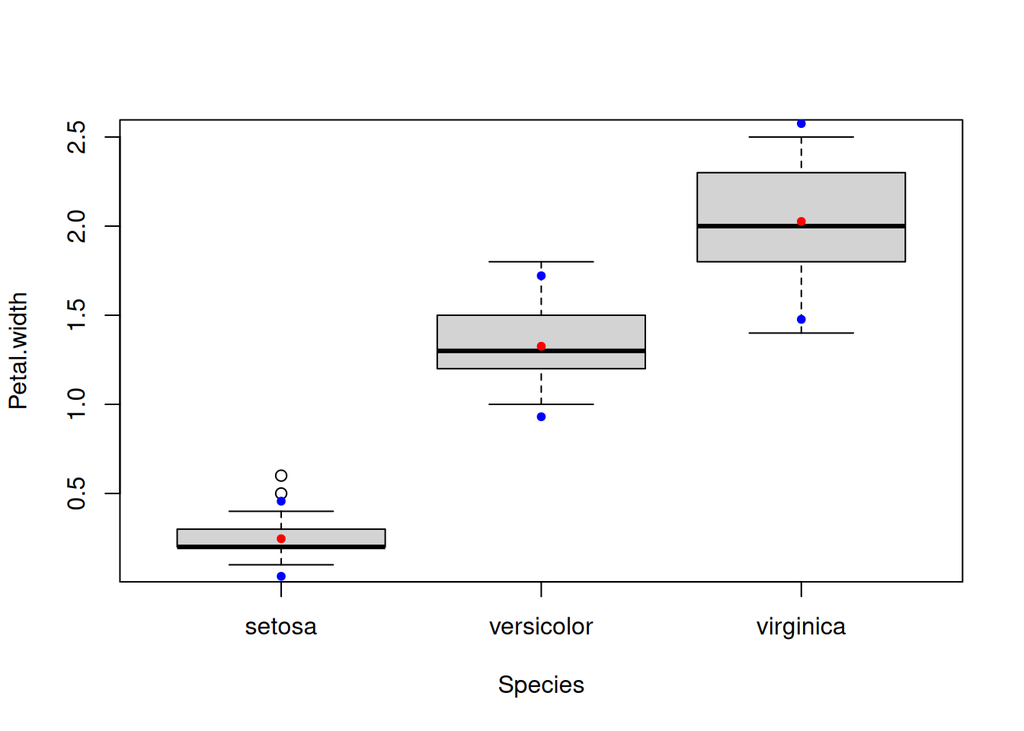

```
##           class
## statistics setosa versicolor virginica Petal.width
##   count    50.000     50.000    50.000     150.000
##   mean      0.246      1.326     2.026       1.199
##   variance  0.011      0.039     0.075       0.581
```

```r
breakd(Petal.width,Species)
```

```r
lm4                 <- lm(Petal.width~Species-1)
sum.lm(lm4)
```

```
##
## Call:
## lm(formula = Petal.width ~ Species - 1)
##
## Residuals:
##    Min     1Q Median     3Q    Max
## -0.626 -0.126 -0.026  0.154  0.474
##
## Coefficients:
##                             2.5 %  97.5 % Std. Error t value Pr(>|t|)
## Speciessetosa     0.24600 0.18880 0.30320    0.02894    8.50 1.96e-14 ***
## Speciesversicolor 1.32600 1.26880 1.38320    0.02894   45.82  < 2e-16 ***
## Speciesvirginica  2.02600 1.96880 2.08320    0.02894   70.00  < 2e-16 ***
## ---
## Signif. codes:  0 '***' 0.001 '**' 0.01 '*' 0.05 '.' 0.1 ' ' 1
##
## Residual standard error: 0.2047 on 147 degrees of freedom
## Multiple R-squared:  0.9796, Adjusted R-squared:  0.9792
## F-statistic:  2357 on 3 and 147 DF,  p-value: < 2.2e-16
```

```r
cat("n prueba de homocedasticidad \n")
```

```
## n prueba de homocedasticidad
```

```r
ncvTest(lm4)                                                # NCV test
```

```
## Non-constant Variance Score Test
## Variance formula: ~ fitted.values
## Chisquare = 28.51394, Df = 1, p = 9.3026e-08
```

```r
cat("n prueba de normalidad \n")
```

```
## n prueba de normalidad
```

```r
shapiro.test(lm4$residuals)
```

```
##
##  Shapiro-Wilk normality test
##
## data:  lm4$residuals
## W = 0.97217, p-value = 0.003866
```

```r
Anova(lm4)
```

```
## Anova Table (Type II tests)
##
## Response: Petal.width
##            Sum Sq  Df F value    Pr(>F)
## Species   296.173   3  2357.2 < 2.2e-16 ***
## Residuals   6.157 147
## ---
## Signif. codes:  0 '***' 0.001 '**' 0.01 '*' 0.05 '.' 0.1 ' ' 1
```

```r
detach(iris)
```

*En este caso también las pruebas no cumplidas no permited de correr la prueba anova, aún la varianza explicada para los promedios 0.246, 1.326 y 2.026 es de 98% del total. Efectivamente las varianzas 0.011, 0.038 0.074 son muy diferentes entre ellas.*

## 6 instalar el paquete R “palmerpenguins”.

El archivo “penguins” tiene mediciones de picos y aletas de los penguinos, según tres especies, tres islas y el sexo.

```r
#install.packages("palmerpenguins")
library(palmerpenguins)
data("penguins")
str(penguins)
```

```
## tibble [344 × 8] (S3: tbl_df/tbl/data.frame)
##  $ species          : Factor w/ 3 levels "Adelie","Chinstrap",..: 1 1 1 1 1 1 1 1 1 1 ...
##  $ island           : Factor w/ 3 levels "Biscoe","Dream",..: 3 3 3 3 3 3 3 3 3 3 ...
##  $ bill_length_mm   : num [1:344] 39.1 39.5 40.3 NA 36.7 39.3 38.9 39.2 34.1 42 ...
##  $ bill_depth_mm    : num [1:344] 18.7 17.4 18 NA 19.3 20.6 17.8 19.6 18.1 20.2 ...
##  $ flipper_length_mm: int [1:344] 181 186 195 NA 193 190 181 195 193 190 ...
##  $ body_mass_g      : int [1:344] 3750 3800 3250 NA 3450 3650 3625 4675 3475 4250 ...
##  $ sex              : Factor w/ 2 levels "female","male": 2 1 1 NA 1 2 1 2 NA NA ...
##  $ year             : int [1:344] 2007 2007 2007 2007 2007 2007 2007 2007 2007 2007 ...
```

```r
penguins$year       <- factor(penguins$year)
penguin             <- na.omit(penguins)
```

## 7 Correr el anova de las tres mediciones

considerando la especie, el sexo y la interacción

*### Anova de la longitud del pico*

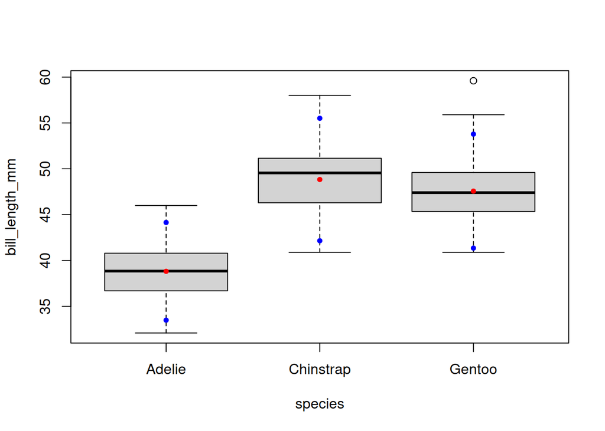

```
##           class
## statistics  Adelie Chinstrap  Gentoo bill_length_mm
##   count    146.000    68.000 119.000        333.000
##   mean      38.824    48.834  47.568         43.993
##   variance   7.089    11.151   9.648         29.906
```

```r
attach(penguin)
lmp1                <- lm(bill_length_mm~species*sex-1,dat=penguin)
breakd(bill_length_mm,species)
```

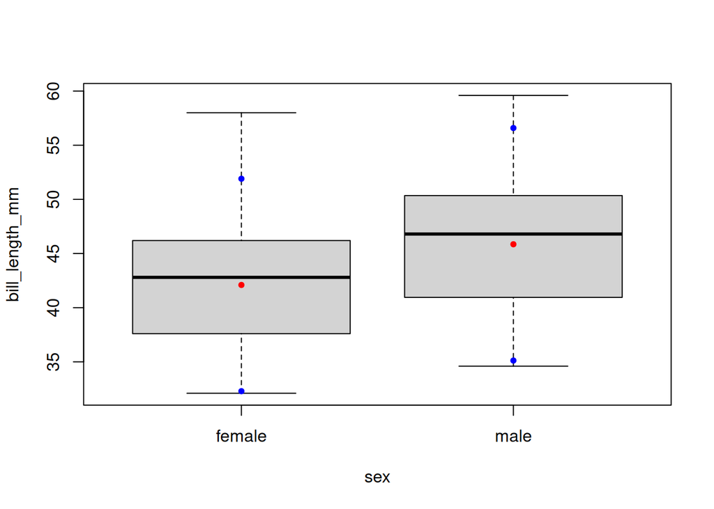

```
##           class
## statistics  female    male bill_length_mm
##   count    165.000 168.000        333.000
##   mean      42.097  45.855         43.993
##   variance  24.044  28.804         29.906
```

```r
breakd(bill_length_mm,sex)
```

```r
cat("n table species by sex \n")
```

```
## n table species by sex
```

```r
table(species,sex)
```

```
##            sex
## species     female male
##   Adelie        73   73
##   Chinstrap     34   34
##   Gentoo        58   61
```

```r
cat("n means by species by sex \n")
```

```
## n means by species by sex
```

```r
tapply(bill_length_mm,list(species,sex),mean)
```

```
##             female     male
## Adelie    37.25753 40.39041
## Chinstrap 46.57353 51.09412
## Gentoo    45.56379 49.47377
```

```r
cat("n variances by species by sex \n")
```

```
## n variances by species by sex
```

```r
tapply(bill_length_mm,list(species,sex),var)
```

```
##             female     male
## Adelie    4.116366 5.185323
## Chinstrap 9.663824 2.447843
## Gentoo    4.207613 7.401634
```

```r
sum.lm(lmp1)
```

```
##
## Call:
## lm(formula = bill_length_mm ~ species * sex - 1, data = penguin)
##
## Residuals:
##     Min      1Q  Median      3Q     Max
## -5.7904 -1.3735 -0.0638  1.2096 11.4265
##
## Coefficients:
##                                      2.5 %   97.5 % Std. Error t value Pr(>|t|)
## speciesAdelie            37.25753 36.72438 37.79069    0.27102 137.473  < 2e-16 ***
## speciesChinstrap         46.57353 45.79230 47.35476    0.39712 117.279  < 2e-16 ***
## speciesGentoo            45.56379 44.96565 46.16193    0.30405 149.856  < 2e-16 ***
## sexmale                   3.13288  2.37888  3.88688    0.38328   8.174 6.64e-15 ***
## speciesChinstrap:sexmale  1.38771  0.05012  2.72530    0.67993   2.041   0.0421 *
## speciesGentoo:sexmale     0.77710 -0.34827  1.90247    0.57206   1.358   0.1753
## ---
## Signif. codes:  0 '***' 0.001 '**' 0.01 '*' 0.05 '.' 0.1 ' ' 1
##
## Residual standard error: 2.316 on 327 degrees of freedom
## Multiple R-squared:  0.9973, Adjusted R-squared:  0.9973
## F-statistic: 2.029e+04 on 6 and 327 DF,  p-value: < 2.2e-16
```

```r
cat("n prueba de homocedasticidad \n")
```

```
## n prueba de homocedasticidad
```

```r
ncvTest(lmp1)                                                # NCV test
```

```
## Non-constant Variance Score Test
## Variance formula: ~ fitted.values
## Chisquare = 1.655985, Df = 1, p = 0.19815
```

```r
cat("n prueba de normalidad \n")
```

```
## n prueba de normalidad
```

```r
shapiro.test(lmp1$residuals)
```

```
##
##  Shapiro-Wilk normality test
##
## data:  lmp1$residuals
## W = 0.97122, p-value = 3.455e-06
```

```r
Anova(lmp1)
```

```
## Anova Table (Type II tests)
##
## Response: bill_length_mm
##             Sum Sq  Df    F value Pr(>F)
## species     299381   3 18611.6611 <2e-16 ***
## sex           1136   1   211.8066 <2e-16 ***
## species:sex     24   2     2.2841 0.1035
## Residuals     1753 327
## ---
## Signif. codes:  0 '***' 0.001 '**' 0.01 '*' 0.05 '.' 0.1 ' ' 1
```

*La longitud del pico tiene varianza constante, pero no cumple con el presupuesto de normalidad. Por otro lado, las diferencias de promedios son significativas para especie y sexo, pero no significativa resulta la interacción. Efectivamente, por el penguino de Adelia y por todas las hembras el pico resulta más corto. Nóte-se que solo los promedios de las especies femininas se resultan datos, los demás resultando como diferencias.*

### 7.1 Anova de profundidad del pico

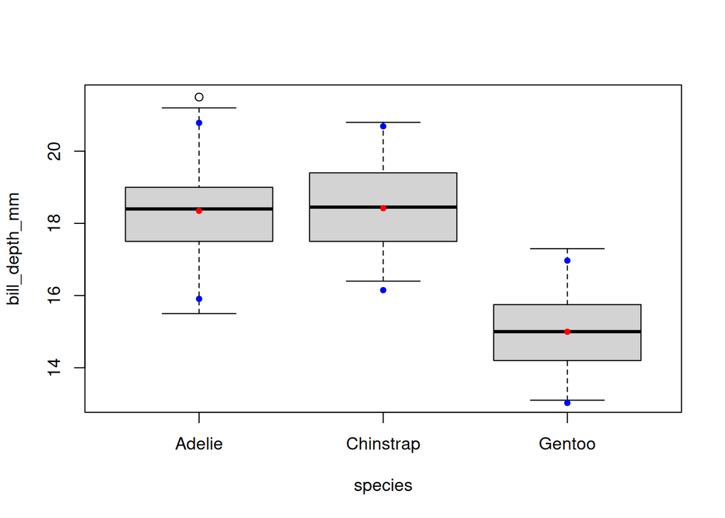

```
##           class
## statistics  Adelie Chinstrap  Gentoo bill_depth_mm
##   count    146.000    68.000 119.000       333.000
##   mean      18.347    18.421  14.997        17.165
##   variance   1.487     1.289   0.972         3.878
```

```r
lmp2                <- lm(bill_depth_mm~species*sex-1,data=penguin)
breakd(bill_depth_mm,species)
```

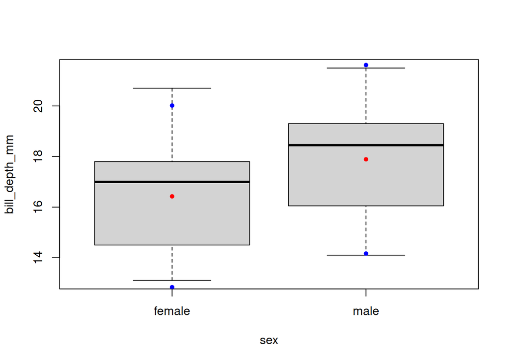

```
##           class
## statistics  female    male bill_depth_mm
##   count    165.000 168.000       333.000
##   mean      16.425  17.891        17.165
##   variance   3.224   3.472         3.878
```

```r
breakd(bill_depth_mm,sex)
```

```r
cat("n table species by sex \n")
```

```
## n table species by sex
```

```r
table(species,sex)
```

```
##            sex
## species     female male
##   Adelie        73   73
##   Chinstrap     34   34
##   Gentoo        58   61
```

```r
cat("n means by species by sex \n")
```

```
## n means by species by sex
```

```r
tapply(bill_depth_mm,list(species,sex),mean)
```

```
##             female     male
## Adelie    17.62192 19.07260
## Chinstrap 17.58824 19.25294
## Gentoo    14.23793 15.71803
```

```r
cat("n variances by species by sex \n")
```

```
## n variances by species by sex
```

```r
tapply(bill_depth_mm,list(species,sex),var)
```

```
##              female      male
## Adelie    0.8892352 1.0381279
## Chinstrap 0.6101604 0.5795365
## Gentoo    0.2918693 0.5491694
```

```r
sum.lm(lmp2)
```

```
##
## Call:
## lm(formula = bill_depth_mm ~ species * sex - 1, data = penguin)
##
## Residuals:
##      Min       1Q   Median       3Q      Max
## -2.12192 -0.57260 -0.02192  0.46207  3.07808
##
## Coefficients:
##                                      2.5 %   97.5 % Std. Error t value Pr(>|t|)
## speciesAdelie            17.62192 17.42982 17.81402    0.09765 180.462   <2e-16 ***
## speciesChinstrap         17.58824 17.30676 17.86972    0.14308 122.923   <2e-16 ***
## speciesGentoo            14.23793 14.02242 14.45344    0.10955 129.967   <2e-16 ***
## sexmale                   1.45068  1.17902  1.72235    0.13810  10.505   <2e-16 ***
## speciesChinstrap:sexmale  0.21402 -0.26792  0.69596    0.24498   0.874    0.383
## speciesGentoo:sexmale     0.02942 -0.37606  0.43489    0.20611   0.143    0.887
## ---
## Signif. codes:  0 '***' 0.001 '**' 0.01 '*' 0.05 '.' 0.1 ' ' 1
##
## Residual standard error: 0.8343 on 327 degrees of freedom
## Multiple R-squared:  0.9977, Adjusted R-squared:  0.9977
## F-statistic: 2.375e+04 on 6 and 327 DF,  p-value: < 2.2e-16
```

```r
cat("n prueba de homocedasticidad \n")
```

```
## n prueba de homocedasticidad
```

```r
ncvTest(lmp2)                                                # NCV test
```

```
## Non-constant Variance Score Test
## Variance formula: ~ fitted.values
## Chisquare = 15.51274, Df = 1, p = 8.1951e-05
```

```r
cat("n prueba de normalidad \n")
```

```
## n prueba de normalidad
```

```r
shapiro.test(lmp2$residuals)
```

```
##
##  Shapiro-Wilk normality test
##
## data:  lmp2$residuals
## W = 0.99076, p-value = 0.03465
```

```r
Anova(lmp2)
```

```
## Anova Table (Type II tests)
##
## Response: bill_depth_mm
##             Sum Sq  Df   F value Pr(>F)
## species      45397   3 21739.360 <2e-16 ***
## sex            188   1   270.800 <2e-16 ***
## species:sex      1   2     0.402 0.6693
## Residuals      228 327
## ---
## Signif. codes:  0 '***' 0.001 '**' 0.01 '*' 0.05 '.' 0.1 ' ' 1
```

*En este caso, las hembras y los penguinos Gentoo parecen tener el pico menos profundo de los demás, pero no result interacción. Nóte-se que en este caso no se cumple con ambos presupuestos de homocedasticidad y normalidad.*

*### Anova de longitud de las aletas*

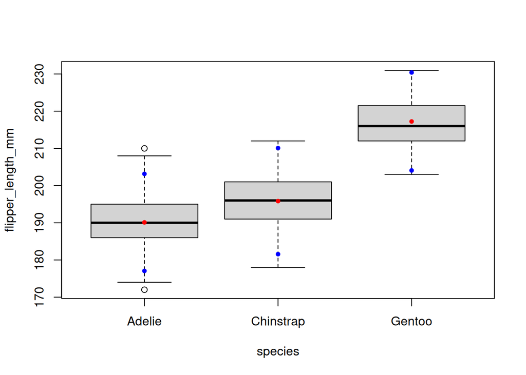

```
##           class
## statistics  Adelie Chinstrap  Gentoo flipper_length_mm
##   count    146.000    68.000 119.000           333.000
##   mean     190.103   195.824 217.235           200.967
##   variance  42.534    50.864  43.368           196.442
```

```r
lmp3                <- lm(flipper_length_mm~species*sex-1,data=penguin)
breakd(flipper_length_mm,species)
```

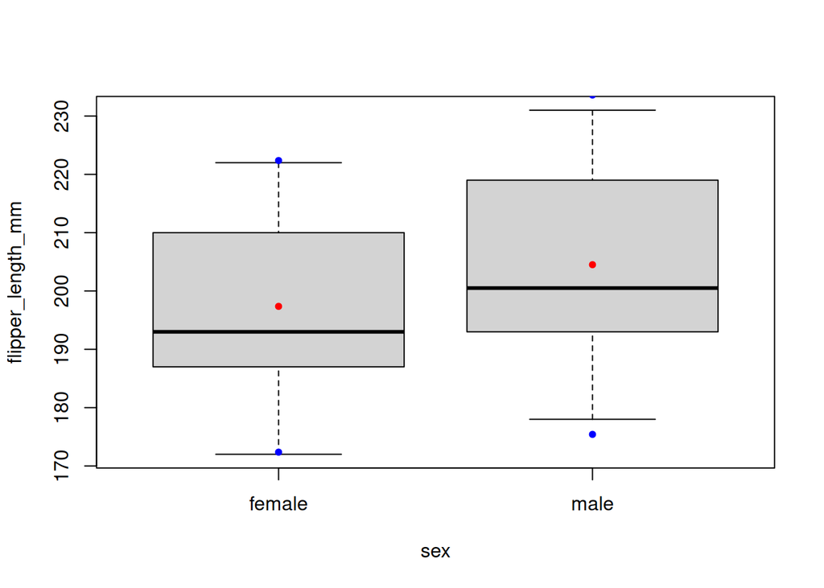

```
##           class
## statistics  female    male flipper_length_mm
##   count    165.000 168.000           333.000
##   mean     197.364 204.506           200.967
##   variance 156.269 211.641           196.442
```

```r
breakd(flipper_length_mm,sex)
```

```r
cat("n table species by sex \n")
```

```
## n table species by sex
```

```r
table(species,sex)
```

```
##            sex
## species     female male
##   Adelie        73   73
##   Chinstrap     34   34
##   Gentoo        58   61
```

```r
cat("n means by species by sex \n")
```

```
## n means by species by sex
```

```r
tapply(flipper_length_mm,list(species,sex),mean)
```

```
##             female     male
## Adelie    187.7945 192.4110
## Chinstrap 191.7353 199.9118
## Gentoo    212.7069 221.5410
```

```r
cat("n variances by species by sex \n")
```

```
## n variances by species by sex
```

```r
tapply(flipper_length_mm,list(species,sex),var)
```

```
##             female     male
## Adelie    31.30441 43.55099
## Chinstrap 33.10963 35.71925
## Gentoo    15.19328 32.18579
```

```r
sum.lm(lmp3)
```

```
##
## Call:
## lm(formula = flipper_length_mm ~ species * sex - 1, data = penguin)
##
## Residuals:
##      Min       1Q   Median       3Q      Max
## -15.7945  -3.4110   0.0882   3.4590  17.5890
##
## Coefficients:
##                                      2.5 %   97.5 % Std. Error t value Pr(>|t|)
## speciesAdelie            187.7945 186.4924 189.0966     0.6619 283.721  < 2e-16 ***
## speciesChinstrap         191.7353 189.8273 193.6433     0.9699 197.692  < 2e-16 ***
## speciesGentoo            212.7069 211.2461 214.1677     0.7426 286.446  < 2e-16 ***
## sexmale                    4.6164   2.7750   6.4579     0.9361   4.932  1.3e-06 ***
## speciesChinstrap:sexmale   3.5600   0.2933   6.8268     1.6606   2.144  0.03278 *
## speciesGentoo:sexmale      4.2176   1.4692   6.9661     1.3971   3.019  0.00274 **
## ---
## Signif. codes:  0 '***' 0.001 '**' 0.01 '*' 0.05 '.' 0.1 ' ' 1
##
## Residual standard error: 5.655 on 327 degrees of freedom
## Multiple R-squared:  0.9992, Adjusted R-squared:  0.9992
## F-statistic: 7.037e+04 on 6 and 327 DF,  p-value: < 2.2e-16
```

```r
cat("n prueba de homocedasticidad \n")
```

```
## n prueba de homocedasticidad
```

```r
ncvTest(lmp3)                                                # NCV test
```

```
## Non-constant Variance Score Test
## Variance formula: ~ fitted.values
## Chisquare = 2.98289, Df = 1, p = 0.084149
```

```r
cat("n prueba de normalidad \n")
```

```
## n prueba de normalidad
```

```r
shapiro.test(lmp3$residuals)
```

```
##
##  Shapiro-Wilk normality test
##
## data:  lmp3$residuals
## W = 0.99548, p-value = 0.448
```

```r
Anova(lmp3)
```

```
## Anova Table (Type II tests)
##
## Response: flipper_length_mm
##              Sum Sq  Df    F value    Pr(>F)
## species     6477332   3 67510.2279 < 2.2e-16 ***
## sex            3906   1   122.1189 < 2.2e-16 ***
## species:sex     329   2     5.1442  0.006314 **
## Residuals     10458 327
## ---
## Signif. codes:  0 '***' 0.001 '**' 0.01 '*' 0.05 '.' 0.1 ' ' 1
```

*Las aletas cumplen con ambos presupuestos y el anova presenta interacción significativa entre sexo y especie. Los hombres y los Gentoo tienen aletas más grandes. Además, el aumento de los hombres Chinstrap y sobre todo Gentoo se resulta mucho mayor de los demás.*

*### Anova de masa del cuerpo*

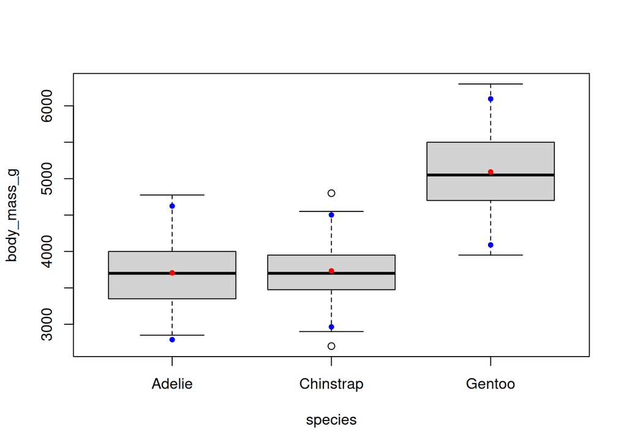

```
##           class
## statistics     Adelie  Chinstrap     Gentoo body_mass_g
##   count       146.000     68.000    119.000     333.000
##   mean       3706.164   3733.088   5092.437    4207.057
##   variance 210332.428 147713.455 251478.333  648372.488
```

```r
lmp4                <- lm(body_mass_g~species*sex-1,data=penguin)
breakd(body_mass_g,species)
```

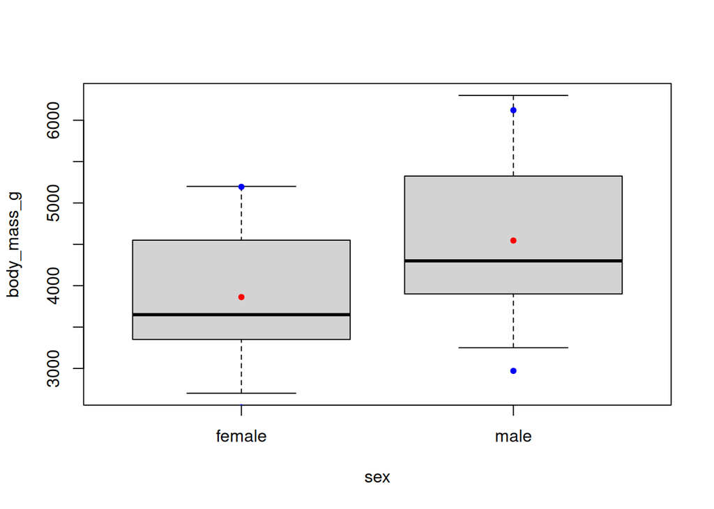

```
##           class
## statistics     female       male body_mass_g
##   count       165.000    168.000     333.000
##   mean       3862.273   4545.685    4207.057
##   variance 443785.200 620359.259  648372.488
```

```r
breakd(body_mass_g,sex)
```

```r
cat("n table species by sex \n")
```

```
## n table species by sex
```

```r
table(species,sex)
```

```
##            sex
## species     female male
##   Adelie        73   73
##   Chinstrap     34   34
##   Gentoo        58   61
```

```r
cat("n means by species by sex \n")
```

```
## n means by species by sex
```

```r
tapply(body_mass_g,list(species,sex),mean)
```

```
##             female     male
## Adelie    3368.836 4043.493
## Chinstrap 3527.206 3938.971
## Gentoo    4679.741 5484.836
```

```r
cat("n variances by species by sex \n")
```

```
## n variances by species by sex
```

```r
tapply(body_mass_g,list(species,sex),var)
```

```
##             female      male
## Adelie    72565.64 120278.25
## Chinstrap 81415.44 131143.61
## Gentoo    79286.34  98068.31
```

```r
sum.lm(lmp4)
```

```
##
## Call:
## lm(formula = body_mass_g ~ species * sex - 1, data = penguin)
##
## Residuals:
##     Min      1Q  Median      3Q     Max
## -827.21 -213.97   11.03  206.51  861.03
##
## Coefficients:
##                                    2.5 %  97.5 % Std. Error t value Pr(>|t|)
## speciesAdelie            3368.84 3297.60 3440.07      36.21  93.030  < 2e-16 ***
## speciesChinstrap         3527.21 3422.82 3631.59      53.06  66.474  < 2e-16 ***
## speciesGentoo            4679.74 4599.82 4759.66      40.63 115.191  < 2e-16 ***
## sexmale                   674.66  573.91  775.40      51.21  13.174  < 2e-16 ***
## speciesChinstrap:sexmale -262.89 -441.62  -84.17      90.85  -2.894  0.00406 **
## speciesGentoo:sexmale     130.44  -19.93  280.80      76.44   1.706  0.08886 .
## ---
## Signif. codes:  0 '***' 0.001 '**' 0.01 '*' 0.05 '.' 0.1 ' ' 1
##
## Residual standard error: 309.4 on 327 degrees of freedom
## Multiple R-squared:  0.9949, Adjusted R-squared:  0.9948
## F-statistic: 1.058e+04 on 6 and 327 DF,  p-value: < 2.2e-16
```

```r
cat("n prueba de homocedasticidad \n")
```

```
## n prueba de homocedasticidad
```

```r
ncvTest(lmp4)                                                # NCV test
```

```
## Non-constant Variance Score Test
## Variance formula: ~ fitted.values
## Chisquare = 0.2339297, Df = 1, p = 0.62863
```

```r
cat("n prueba de normalidad \n")
```

```
## n prueba de normalidad
```

```r
shapiro.test(lmp4$residuals)
```

```
##
##  Shapiro-Wilk normality test
##
## data:  lmp4$residuals
## W = 0.99776, p-value = 0.9367
```

```r
Anova(lmp4)
```

```
## Anova Table (Type II tests)
##
## Response: body_mass_g
##                 Sum Sq  Df  F value    Pr(>F)
## species     2604731436   3 9070.028 < 2.2e-16 ***
## sex           37090262   1  387.460 < 2.2e-16 ***
## species:sex    1676557   2    8.757 0.0001973 ***
## Residuals     31302628 327
## ---
## Signif. codes:  0 '***' 0.001 '**' 0.01 '*' 0.05 '.' 0.1 ' ' 1
```

*Aquí también se resultan lo hombres y los Gentoo más pesados de los demás. Pero se resulta que la diferencia entre machos y hembras es mucho menor de las demás para los Chinstrap. La masa de cuerpo se resulta cumplir con los presupuestos.*

*En general, se resultan mediciones mayores para los penguinos machos y los Gentoo por lo menos. ¿Se cumplen los requisitos? ¿Que se resulta?

*No siempre se cumplen los requisitos de homocedasticidad y normalidad. Esto limita la aplicación de la anova ya que la estimación de la varianza no es más posible. De consecuencia las probabilidades asociadas a las estadísticas solo cuantifican la relevancia de las diferencias observadas, pero no pueden ser empleadas estadísticamente.*

*De todo modo, las anovas muestran una calidad muy alta, con un $R^2$ igual a .82, .82, .84 y .85 respectivamente. Este valor mejora mucho cuando se tira el intercepta en el modelo, llegando a 99.7, 99.8, 99.9 y 99.5 respectivamente. La interacción resulta significativa solo para aletas y masa.*

¿Y que tal ajuntando las islas?

```r
ftable(species,sex,island)
```

```
##                  island Biscoe Dream Torgersen
## species   sex
## Adelie    female            22    27        24
##           male              22    28        23
## Chinstrap female             0    34         0
##           male               0    34         0
## Gentoo    female            58     0         0
##           male              61     0         0
```

```r
detach(penguin)
```

*Como solo los penguinos Adelie se encuentran en todas las tres islas, se resultan valores faltantes que complican el estudio. Limitamos el estudio a solo penguinos Adelia, monstrando los resultados solo para la longitud del pico.*

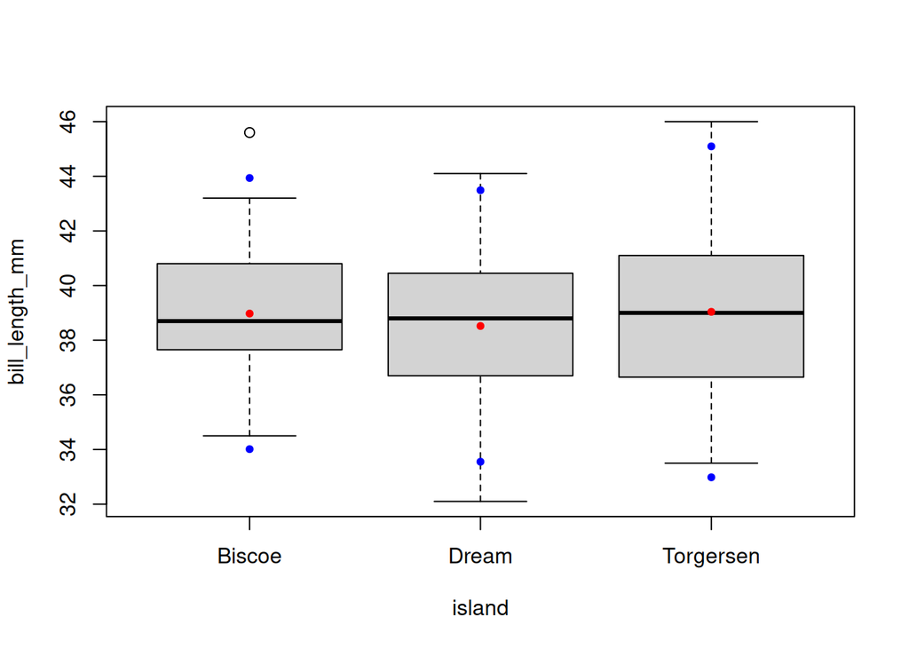

```
##           class
## statistics Biscoe  Dream Torgersen bill_length_mm
##   count    44.000 55.000    47.000        146.000
##   mean     38.975 38.520    39.038         38.824
##   variance  6.155  6.172     9.169          7.089
```

```r
pengadelia          <- penguin[which(penguin$species=="Adelie"),]
attach(pengadelia)
breakd(bill_length_mm,island)
```

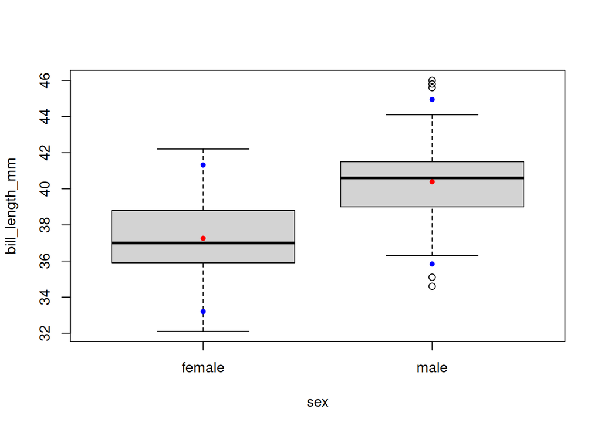

```
##           class
## statistics female   male bill_length_mm
##   count    73.000 73.000        146.000
##   mean     37.258 40.390         38.824
##   variance  4.116  5.185          7.089
```

```r
breakd(bill_length_mm,sex)
```

```r
lmp5                <- lm(bill_length_mm~island*sex)
cat("n table island by sex \n")
```

```
## n table island by sex
```

```r
table(island,sex)
```

```
##            sex
## island      female male
##   Biscoe        22   22
##   Dream         27   28
##   Torgersen     24   23
```

```r
cat("n means by island by sex \n")
```

```
## n means by island by sex
```

```r
tapply(bill_length_mm,list(island,sex),mean)
```

```
##             female     male
## Biscoe    37.35909 40.59091
## Dream     36.91111 40.07143
## Torgersen 37.55417 40.58696
```

```r
cat("n variances by island by sex \n")
```

```
## n variances by island by sex
```

```r
tapply(bill_length_mm,list(island,sex),var)
```

```
##             female     male
## Biscoe    3.105390 4.026580
## Dream     4.364103 3.056190
## Torgersen 4.874764 9.165731
```

```r
sum.lm(lmp5)
```

```
##
## Call:
## lm(formula = bill_length_mm ~ island * sex)
##
## Residuals:
##     Min      1Q  Median      3Q     Max
## -5.9870 -1.3542  0.1087  1.2378  5.4130
##
## Coefficients:
##                                   2.5 %  97.5 % Std. Error t value Pr(>|t|)
## (Intercept)             37.3591 36.4442 38.2740     0.4627  80.734  < 2e-16 ***
## islandDream             -0.4480 -1.6804  0.7845     0.6234  -0.719    0.474
## islandTorgersen          0.1951 -1.0715  1.4616     0.6406   0.305    0.761
## sexmale                  3.2318  1.9380  4.5256     0.6544   4.938 2.21e-06 ***
## islandDream:sexmale     -0.0715 -1.8075  1.6645     0.8781  -0.081    0.935
## islandTorgersen:sexmale -0.1990 -1.9995  1.6015     0.9107  -0.219    0.827
## ---
## Signif. codes:  0 '***' 0.001 '**' 0.01 '*' 0.05 '.' 0.1 ' ' 1
##
## Residual standard error: 2.17 on 140 degrees of freedom
## Multiple R-squared:  0.3584, Adjusted R-squared:  0.3355
## F-statistic: 15.64 on 5 and 140 DF,  p-value: 3.243e-12
```

```r
cat("n prueba de homocedasticidad \n")
```

```
## n prueba de homocedasticidad
```

```r
ncvTest(lmp5)                                                # NCV test
```

```
## Non-constant Variance Score Test
## Variance formula: ~ fitted.values
## Chisquare = 1.55472, Df = 1, p = 0.21244
```

```r
cat("n prueba de normalidad \n")
```

```
## n prueba de normalidad
```

```r
shapiro.test(lmp5$residuals)
```

```
##
##  Shapiro-Wilk normality test
##
## data:  lmp5$residuals
## W = 0.99354, p-value = 0.7581
```

```r
Anova(lmp5)
```

```
## Anova Table (Type II tests)
##
## Response: bill_length_mm
##            Sum Sq  Df F value    Pr(>F)
## island       9.97   2  1.0579    0.3499
## sex        359.97   1 76.4122 6.426e-15 ***
## island:sex   0.23   2  0.0248    0.9755
## Residuals  659.52 140
## ---
## Signif. codes:  0 '***' 0.001 '**' 0.01 '*' 0.05 '.' 0.1 ' ' 1
```

*Las anovas indican que no hay ninguna influencia de las islas sobre los promedios ni siquiera su interacción con el sexo de las mediciones de los penguinos Adelia y por lo tanto no se muestran los resultados.*

## 8 escribir un reporte,

incluyendo los resultados y los gráficos relevantes, comentando los resultados conseguidos.

*Por falta de tiempo, no pude tratar el reporte.*

## 9 guardar los datos,

los archivos .Rmd y .html y enviar todos a sergio@camiz.it dentro del 25 de Mayo.